# Rhodiola rosea — Elemental Impurity Monte Carlo Screening

Reproducible supplementary analysis (deterministic HI and As-based CR)

Author

B. Mestav, Department of Statistics — Project THD-2025-5312

Published

October 20, 2026

## Overview

This document reproduces the screening analysis reported in the manuscript: the **deterministic lower-bound hazard index (HI) and arsenic-based cancer screening index (CR_As)** (Table 4) and the **Monte Carlo 95th-percentile outputs** under lower-, middle- and upper-bound substitution of censored measurements (Table 5), together with Figure 1 (lead concentrations) and Figure 2 (HI scenarios).

**Model.** `EDI = C(mg/kg) × IR(g/day) × 1e-3 / BW`; `HQ_e = EDI_e / RfD_e`; `HI = Σ HQ` over {As, Cd, Ni, Hg, Co, V, Sb, Sn} (Pb and total Cr excluded). Cancer screening (inorganic-As only): `LADD_As = EDI_As × (ED/LT)`, `CR_As = LADD_As × CSF_As`. Constants: `ED=30 y, LT=70 y, EF=365, AT=EF·ED, CF=1e-3, BW~Uniform(50,90) kg, N=10000, seed=20260805`. Censoring (LB/MB/UB): `<MLoD → 0 / MLoD/2 / MLoD`; `<MLoQ → 0 / MLoQ/2 / MLoQ`.

## Setup: data, limits and functions

```python
import numpy as np
import pandas as pd

EL = ['As','Cd','Pb','Cr','Ni','Hg','Co','V','Sb','Sn']

# Table-4 censored concentrations (mg/kg). 'D'=<MLoD, 'Q'=<MLoQ
T4 = {
 'S1' :[240.7909,'D',2.6983,43.3909,1.0378,'D','D',37.7431,0.2185,0.4697],
 'S2' :[283.9054,3.0693,7.4037,53.1243,4.7635,'D',11.4081,40.165,0.275,1.0231],
 'S3' :[200.7309,'Q',2.3367,92.4474,1.5282,'D',9.4352,24.629,0.2215,0.6977],
 'S4' :['Q','D',1.5386,25.3708,0.7084,'D',0.5424,2.1253,0.2214,'Q'],
 'S5' :['D','D',1.7837,'Q','Q','D','Q',1.1341,0.2202,'Q'],
 'S6' :['D','D',2.3413,'D',1.5424,'D',0.4549,0.921,0.1775,'Q'],
 'S7' :['Q','D',2.3862,16.4394,14.8669,'D',1.2866,3.1449,0.1869,'Q'],
 'S8' :['Q','Q',2.1049,18.9112,16.4426,'D',1.3335,3.1078,0.2094,0.1433],
 'S9' :['D','D',1.9894,16.8279,21.1035,'D',1.0552,2.7149,0.1649,0.4726],
 'S10':['D','D',1.3051,4.1127,3.8824,'D',0.3729,1.0748,0.1097,'Q'],
 'S11':['Q','Q',1.6274,4.1896,5.861,'D',0.5608,1.3855,0.099,'D'],
 'S12':['Q','D',2.0189,82.9713,5.6287,'D',0.6583,1.6129,0.0878,'Q'],
 'S13':['Q','D',2.8387,'D',2.0824,'D',0.3178,0.1754,0.0767,'Q'],
 'S14':['D','D',1.5175,17.9459,1.0227,'D','D','D',0.044,'D'],
 'S15':['D','D',1.8659,4.2417,50.6617,'D',0.7702,'D',0.0542,'D'],
 'S16':['D','D',1.0437,'D',1.7908,'D',0.3845,'D','Q','D'],
 'S17':['D','D',5.5885,2.152,0.8564,'D',0.3074,'D','D','D'],
 'S18':['D','D',3.1078,'Q',9.2906,'D','Q','D','Q','D'],
}
PROD = {s:p for s,p in zip(T4, sum([[c]*3 for c in 'ABCDEF'],[]))}
IR   = {'A':0.20,'B':0.25,'C':0.35,'D':0.25,'E':0.25,'F':0.25}  # g/day

MLoD = {'As':0.550,'Cd':0.689,'Pb':0.248,'Cr':0.159,'Ni':0.136,
        'Hg':1.470,'Co':0.0834,'V':0.0461,'Sb':0.0121,'Sn':0.0351}
MLoQ = {e: MLoD[e]*3.33 for e in EL}
MLoQ.update({'As':1.833,'Cd':2.293,'Pb':0.823,'Hg':4.894})

RfD = {'As':6e-5,'Cd':1e-3,'Ni':2e-2,'Hg':3e-4,'Co':3e-4,'V':5e-3,'Sb':4e-4,'Sn':0.6}
CSF_As = 32.0
EF, ED, LT, CF, N, SEED = 365, 30, 70, 1e-3, 10000, 20260805
AT = EF*ED

def value(e, cell, scen):
    if not isinstance(cell, str): return cell
    if cell == 'D': return {'LB':0.0,'MB':MLoD[e]/2,'UB':MLoD[e]}[scen]
    if cell == 'Q': return {'LB':0.0,'MB':MLoQ[e]/2,'UB':MLoQ[e]}[scen]
    raise ValueError(cell)

def hi_cr(sample, ir, bw):
    hi = sum((sample[e]*ir*CF/bw)/RfD[e] for e in RfD)
    cr = (sample['As']*ir*CF/bw)*(ED/LT)*CSF_As
    return hi, cr
```

## Table 4 — deterministic lower-bound (BW = 70 kg)

```python
rows = []
for s in T4:
    smp = {EL[j]: value(EL[j], T4[s][j], 'LB') for j in range(10)}
    hi, cr = hi_cr(smp, IR[PROD[s]], 70.0)
    rows.append([s, f"Sup_{PROD[s]}", round(hi,4), f"{cr:.2e}"])
tab4 = pd.DataFrame(rows, columns=["Sample","Product","HI (LB)","CR_As (LB)"])
tab4
```

|  | Sample | Product | HI (LB) | CR_As (LB) |
| --- | --- | --- | --- | --- |
| 0 | S1 | Sup_A | 11.4895 | 9.44e-03 |
| 1 | S2 | Sup_A | 13.6623 | 1.11e-02 |
| 2 | S3 | Sup_A | 9.6644 | 7.87e-03 |
| 3 | S4 | Sup_B | 0.0101 | 0.00e+00 |
| 4 | S5 | Sup_B | 0.0028 | 0.00e+00 |
| 5 | S6 | Sup_B | 0.0079 | 0.00e+00 |
| 6 | S7 | Sup_C | 0.0306 | 0.00e+00 |
| 7 | S8 | Sup_C | 0.0321 | 0.00e+00 |
| 8 | S9 | Sup_C | 0.0276 | 0.00e+00 |
| 9 | S10 | Sup_D | 0.0069 | 0.00e+00 |
| 10 | S11 | Sup_D | 0.0096 | 0.00e+00 |
| 11 | S12 | Sup_D | 0.0108 | 0.00e+00 |
| 12 | S13 | Sup_E | 0.0050 | 0.00e+00 |
| 13 | S14 | Sup_E | 0.0006 | 0.00e+00 |
| 14 | S15 | Sup_E | 0.0187 | 0.00e+00 |
| 15 | S16 | Sup_F | 0.0049 | 0.00e+00 |
| 16 | S17 | Sup_F | 0.0038 | 0.00e+00 |
| 17 | S18 | Sup_F | 0.0017 | 0.00e+00 |

## Table 5 — Monte Carlo P95 by product and scenario

```python
P95_HI = {}
rows = []
for scen in ['LB','MB','UB']:
    for p in 'ABCDEF':
        samps = [{EL[j]: value(EL[j], T4[s][j], scen) for j in range(10)}
                 for s in T4 if PROD[s]==p]
        np.random.seed(SEED)                 # reset once per product
        bw  = np.random.uniform(50, 90, N)
        idx = np.random.choice([0,1,2], N)
        HI  = np.array([hi_cr(samps[idx[i]], IR[p], bw[i])[0] for i in range(N)])
        CR  = np.array([hi_cr(samps[idx[i]], IR[p], bw[i])[1] for i in range(N)])
        P95_HI[(scen,p)] = np.percentile(HI,95)
        rows.append([f"Sup_{p}", scen, round(np.percentile(HI,95),3),
                     f"{np.percentile(CR,95):.2e}", round(100*(CR>1e-4).mean(),1)])
tab5 = pd.DataFrame(rows, columns=["Product","Scenario","HI P95","CR_As P95","CR_As>1e-4 (%)"])
tab5
```

|  | Product | Scenario | HI P95 | CR_As P95 | CR_As>1e-4 (%) |
| --- | --- | --- | --- | --- | --- |
| 0 | Sup_A | LB | 17.135 | 1.40e-02 | 100.0 |
| 1 | Sup_B | LB | 0.013 | 0.00e+00 | 0.0 |
| 2 | Sup_C | LB | 0.041 | 0.00e+00 | 0.0 |
| 3 | Sup_D | LB | 0.013 | 0.00e+00 | 0.0 |
| 4 | Sup_E | LB | 0.023 | 0.00e+00 | 0.0 |
| 5 | Sup_F | LB | 0.006 | 0.00e+00 | 0.0 |
| 6 | Sup_A | MB | 17.144 | 1.40e-02 | 100.0 |
| 7 | Sup_B | MB | 0.093 | 5.61e-05 | 0.0 |
| 8 | Sup_C | MB | 0.163 | 8.29e-05 | 0.0 |
| 9 | Sup_D | MB | 0.100 | 5.90e-05 | 0.0 |
| 10 | Sup_E | MB | 0.087 | 5.61e-05 | 0.0 |
| 11 | Sup_F | MB | 0.041 | 1.81e-05 | 0.0 |
| 12 | Sup_A | UB | 17.152 | 1.40e-02 | 100.0 |
| 13 | Sup_B | UB | 0.174 | 1.12e-04 | 10.6 |
| 14 | Sup_C | UB | 0.285 | 1.66e-04 | 63.6 |
| 15 | Sup_D | UB | 0.187 | 1.18e-04 | 21.4 |
| 16 | Sup_E | UB | 0.167 | 1.12e-04 | 10.6 |
| 17 | Sup_F | UB | 0.077 | 3.62e-05 | 0.0 |

## Figure 1 — Lead concentrations in the 18 packages

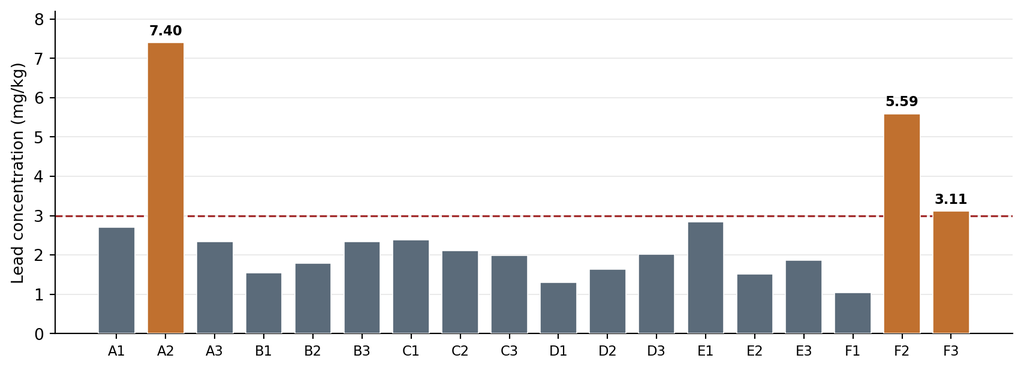

Figure 1: Lead concentrations with the 3.0 mg/kg comparison level; exceedances highlighted.

```python
import matplotlib.pyplot as plt
labs = [f"{c}{k+1}" for c in "ABCDEF" for k in range(3)]
pb   = [T4[f"S{i+1}"][2] for i in range(18)]
exc  = [v > 3.0 for v in pb]
fig, ax = plt.subplots(figsize=(9,3.3))
ax.bar(range(18), pb, width=0.74, zorder=3, edgecolor="white", linewidth=0.6,
       color=["#c0702f" if e else "#5b6b7a" for e in exc])
ax.axhline(3.0, color="#a32d2d", ls="--", lw=1.2)
for i,v in enumerate(pb):
    if exc[i]: ax.text(i, v+0.12, f"{v:.2f}", ha="center", va="bottom", fontsize=8.5, fontweight="bold")
ax.set_xticks(range(18)); ax.set_xticklabels(labs, fontsize=8.5)
ax.set_ylabel("Lead concentration (mg/kg)"); ax.set_ylim(0,8.2)
ax.grid(axis="y", color="#e6e6e6", lw=0.6, zorder=0)
for sp in ("top","right"): ax.spines[sp].set_visible(False)
plt.tight_layout(); plt.show()
```

## Figure 2 — LB/MB/UB P95 hazard index

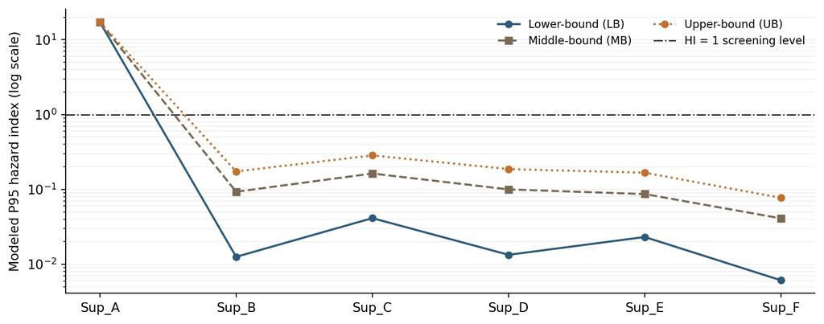

Figure 2: Monte Carlo P95 hazard index under the three substitution scenarios (log scale).

```python
SUP = list("ABCDEF"); x = np.arange(6)
style = {'LB':("#2e5a7a","-","o","Lower-bound (LB)"),
         'MB':("#7a6a55","--","s","Middle-bound (MB)"),
         'UB':("#c0702f",":","o","Upper-bound (UB)")}
fig, ax = plt.subplots(figsize=(9,3.6))
for scen in ['LB','MB','UB']:
    col, ls, mk, lab = style[scen]
    ax.plot(x, [P95_HI[(scen,p)] for p in SUP], ls, color=col, marker=mk, ms=5, lw=1.6, label=lab)
ax.axhline(1, color="#333", ls="-.", lw=1.1, label="HI = 1 screening level")
ax.set_yscale("log"); ax.set_xticks(x); ax.set_xticklabels([f"Sup_{p}" for p in SUP])
ax.set_ylabel("Modeled P95 hazard index (log scale)")
ax.grid(axis="y", which="both", color="#ededed", lw=0.6)
for sp in ("top","right"): ax.spines[sp].set_visible(False)
ax.legend(fontsize=8.5, ncol=2, frameon=False, loc="upper right")
plt.tight_layout(); plt.show()
```

## Notes

- `CR_As` is a **provisional screening index**: total arsenic is assumed 100% inorganic and the Sup_A doses exceed the low-dose range where the 2025 US EPA linear slope factor applies (~0.2 µg/kg-day). It is not a validated lifetime cancer risk.
- P95 proportions are fractions of model iterations, not of consumers.
- Matrix MLoD/MLoQ assume a ~1/100 working dilution; confirmation of the actual weighing/dilution would fix these to exact values.